# INSIDER - PREDICTING CHURN VISITORS

### Introduction

Insider is collecting clickstream data from hundreds of different e-commerce websites. These raw events are continuously being processed to obtain insights about the visitors of our partners.

We provide a lot of different ways to personalize the user experience for our partners. One of them is targeting different user groups for different personalization campaigns using our AI-backed Predictive User Segments such as Likelihood to Purchase, Uninstall Prediction, Discount Affinity etc. .

In this problem, you are asked to model a segment called Likelihood to Churn which predicts whether or not a user will not visit the website again within the next 7 days, as this is the business metric for the data we are providing.

### Problem Description

You are provided with raw clickstream data of an e-commerce website between 1 January 2020 and 27 February 2020 containing around 1.350.000 click events as training dataset.

A clickstream dataset means that each row corresponds to a page view event for an unique user and session. A page view event can be of several types such as cart page view, product page view, success (which means purchase) etc. Each row contains a user id and a session id. User id uniquely identifies a user across the dataset, whereas session id uniquely identifies a session across the dataset.

A session is a group of user interactions with the website that take place within a given time frame, in our case 30 minutes. For example a single session can contain multiple page views, events, social interactions, and ecommerce transactions. See Figure 1 below for an example session with multiple events.

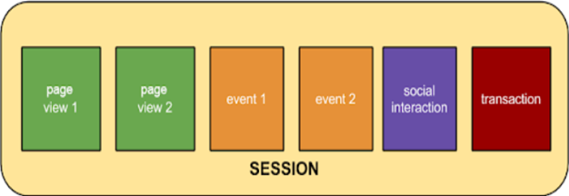

A single user can open multiple sessions. Those sessions can occur on the same day, or over several days, weeks, or months. As soon as one session ends, there is then an opportunity to start a new session. A session ends either after 30 minutes of inactivity or at midnight.

As you are provided with raw clickstream data and your objective is to predict the inverse possibility of a new session in 7 days for each session, first you need to aggregate raw click data to end up with session data so that each row corresponds to a single session. Then you need to label your data with respect to the given objective above. After that you need to train and optimize a predictive model using your favorite framework. Finally, using the trained model you need to predict the possibility of not having a new session within 7 days for each session in the test dataset.

### Generating Predictions

Test dataset is in the very same format of the train dataset. So you need to apply all the data processing techniques you applied to obtain your training dataset so that you can run your model on the test dataset.

The test dataset contains around 178.000 clickstream events for March, however, we have pruned the dataset so that it only contains the very first session of each user. There are around 35.000 unique sessions. You need to generate a prediction for every single session.

```python
import pandas as pd
import numpy as np
from datetime import datetime
import random
from sklearn.model_selection import train_test_split
import xgboost as xgb
from sklearn.metrics import classification_report
from catboost import Pool, CatBoostClassifier, cv
from sklearn.preprocessing import MinMaxScaler
from sklearn.svm import SVC
pd.set_option("display.max_rows",100)
pd.set_option("display.max_columns",300)
```

```python
train=pd.read_parquet('training.snappy.parquet', engine='pyarrow')
test=pd.read_parquet('test.snappy.parquet', engine='pyarrow')
submis=pd.read_csv("samplesubmissionson.csv")
train['date']=pd.to_datetime(train['date'], format='%Y-%m-%d %H:%M:%S')
test['date']=pd.to_datetime(test['date'], format='%Y-%m-%d %H:%M:%S')
```

```python
train.head()
```

|  | date | referrer_url | current_url | page_type | product_price | cart_amount | userid | sessionid | search_words | old_product_price | product_category | page_category | productid |
| --- | --- | --- | --- | --- | --- | --- | --- | --- | --- | --- | --- | --- | --- |
| 0 | 2020-02-06 09:11:12 | 9d206cbddfddaa97c20690adcd6ea802 | 006bde08100ccffb2fa8884e700a49f8 | category | NaN | 0.0 | 3649149be6ac6b2ded1ae8e5778e3f40 | f67ed2ac99c1074b9f19cfe250db7f66 | None | NaN | None | [6408EC06126E8040270C7E8AAF8FC685] | None |
| 1 | 2020-02-06 09:31:58 | 9d206cbddfddaa97c20690adcd6ea802 | 0da33cc234a95c72475b08138062184f | category | NaN | 0.0 | 4972b982adf86f4f2949208f780bc7fa | 726c29cc12d35d7d1bd6b9807ef80d02 | None | NaN | None | [4B6DE4B085D3099FF02A6E1BCDC5D80A] | None |
| 2 | 2020-02-06 09:06:52 | d41d8cd98f00b204e9800998ecf8427e | 9d206cbddfddaa97c20690adcd6ea802 | main | NaN | 0.0 | 933513a2ab574affb218ec782411efe4 | 7f363cc0d075b82cd23cf9894b51a76b | None | NaN | None | None | None |
| 3 | 2020-02-06 09:19:35 | 084bcd33c021da0af9a5565751ccb520 | cb510a4ad895541025ff145a4d8622cb | productDetail | 265000.0 | 0.0 | 84f7184f69b16aa251e49dae53aec70d | b78389be4460f6259488baa73ef4eeac | None | 279000.0 | [53D8DE583EA7608B24D2AAF0EDD90F0B] | None | [B17DAE0CE2664234BFC73EF642E06148] |
| 4 | 2020-02-06 09:31:20 | 9d206cbddfddaa97c20690adcd6ea802 | 5b8ef12a316fe0225500902ecc2e9464 | category | NaN | 0.0 | b2c7ef6fd61fb02b0da2b27da1a3202b | 2b06b0e52bd7f6a8ff7c55042b8dccb9 | None | NaN | None | [277188CEF1BF8E81FCE027D0D857FB3D] | None |

```python
train.page_category.replace(to_replace=[None], value="none",inplace=True)
train.search_words.replace(to_replace=[None], value="none",inplace=True)
train.product_category.replace(to_replace=[None], value="none",inplace=True)
train.productid.replace(to_replace=[None], value="none",inplace=True)
test.page_category.replace(to_replace=[None], value="none",inplace=True)
test.search_words.replace(to_replace=[None], value="none",inplace=True)
test.product_category.replace(to_replace=[None], value="none",inplace=True)
test.productid.replace(to_replace=[None], value="none",inplace=True)
```

```python
train.page_category=train.page_category.apply(lambda x : hash(tuple(x)))
train.product_category=train.product_category.apply(lambda x : hash(tuple(x)))
train.productid=train.productid.apply(lambda x : hash(tuple(x)))
test.page_category=test.page_category.apply(lambda x : hash(tuple(x)))
test.product_category=test.product_category.apply(lambda x : hash(tuple(x)))
test.productid=test.productid.apply(lambda x : hash(tuple(x)))
```

```python
train.head()
```

|  | date | referrer_url | current_url | page_type | product_price | cart_amount | userid | sessionid | search_words | old_product_price | product_category | page_category | productid |
| --- | --- | --- | --- | --- | --- | --- | --- | --- | --- | --- | --- | --- | --- |
| 0 | 2020-02-06 09:11:12 | 9d206cbddfddaa97c20690adcd6ea802 | 006bde08100ccffb2fa8884e700a49f8 | category | NaN | 0.0 | 3649149be6ac6b2ded1ae8e5778e3f40 | f67ed2ac99c1074b9f19cfe250db7f66 | none | NaN | 3938592254412437064 | 1486245975321553305 | 3938592254412437064 |
| 1 | 2020-02-06 09:31:58 | 9d206cbddfddaa97c20690adcd6ea802 | 0da33cc234a95c72475b08138062184f | category | NaN | 0.0 | 4972b982adf86f4f2949208f780bc7fa | 726c29cc12d35d7d1bd6b9807ef80d02 | none | NaN | 3938592254412437064 | -656784331577794791 | 3938592254412437064 |
| 2 | 2020-02-06 09:06:52 | d41d8cd98f00b204e9800998ecf8427e | 9d206cbddfddaa97c20690adcd6ea802 | main | NaN | 0.0 | 933513a2ab574affb218ec782411efe4 | 7f363cc0d075b82cd23cf9894b51a76b | none | NaN | 3938592254412437064 | 3938592254412437064 | 3938592254412437064 |
| 3 | 2020-02-06 09:19:35 | 084bcd33c021da0af9a5565751ccb520 | cb510a4ad895541025ff145a4d8622cb | productDetail | 265000.0 | 0.0 | 84f7184f69b16aa251e49dae53aec70d | b78389be4460f6259488baa73ef4eeac | none | 279000.0 | -8160420955449545553 | 3938592254412437064 | -3820963510517529625 |
| 4 | 2020-02-06 09:31:20 | 9d206cbddfddaa97c20690adcd6ea802 | 5b8ef12a316fe0225500902ecc2e9464 | category | NaN | 0.0 | b2c7ef6fd61fb02b0da2b27da1a3202b | 2b06b0e52bd7f6a8ff7c55042b8dccb9 | none | NaN | 3938592254412437064 | 2615735889361129283 | 3938592254412437064 |

```python
total_sessions=pd.DataFrame(train.groupby("userid")["sessionid"].nunique())
not_churn=total_sessions[total_sessions['sessionid']==1].index.to_list()
df1=train[train['userid'].isin(not_churn)]
df0=train[~train['userid'].isin(not_churn)]
```

```python
total_sessions
```

| userid | sessionid |
| --- | --- |
| 0000a8811d309d99bf87ec6680d38fe9 | 1 |
| 0001b5ef1ffaaac0fe452500cc588e8f | 1 |
| 0001da844668450707f57217271faeb0 | 3 |
| 00026f0193aeaa73d3b01467110e25ac | 1 |
| 000274bfd3306ab0c85b3813b21df110 | 1 |
| ... | ... |
| ffff12a9624534cee93b8db6c39d4ea9 | 1 |
| ffff59c04692ebd2cf6ebb9f15e943c3 | 1 |
| ffff6c0f1da5a8ca4f56add8fdd479f7 | 1 |
| ffffadc2c938a3e2d59faf0261e2e5f5 | 1 |
| ffffe9508f286b6e389bfd1554428d66 | 2 |

211943 rows × 1 columns

```python
df1_userid=df1.userid.unique()
df0_userid=df0.userid.unique()
```

```python
#pd.pivot_table(df1, values='referrer_url', index='userid',columns='product_category', aggfunc=len).reset_index().fillna(0)
```

```python
df1_pivot=pd.pivot_table(df1, values='referrer_url', index='userid',columns='page_type', aggfunc=len).reset_index().fillna(0)
df1_uniques=pd.DataFrame(df1.groupby("userid")["current_url","search_words","productid","page_category","product_category"].nunique()-1).reset_index().fillna(0)
df1_cart_amount=df1.groupby("userid")["cart_amount"].agg(['max','count']).reset_index().rename(columns={'max':'cart_amount_max','count':'cart_amount_count'})
df1_old_product_price=df1.groupby("userid")["old_product_price"].agg(['min', 'max','mean']).reset_index().fillna(0).rename(columns={'min':'old_product_price_min','max':'old_product_price_max','mean':'old_product_price_mean'})
df1_product_price=df1.groupby("userid")["product_price"].agg(['min', 'max','mean']).reset_index().fillna(0).rename(columns={'min':'product_price_min','max':'product_price_max','mean':'product_price_mean'})
df1_date=pd.DataFrame(df1.groupby(["userid"])["date"].max()).reset_index()
```

```python
df1_pivot.head(2)
```

| page_type | userid | cart | category | main | other | productDetail | success |
| --- | --- | --- | --- | --- | --- | --- | --- |
| 0 | 0000a8811d309d99bf87ec6680d38fe9 | 0.0 | 0.0 | 1.0 | 0.0 | 0.0 | 0.0 |
| 1 | 0001b5ef1ffaaac0fe452500cc588e8f | 0.0 | 9.0 | 0.0 | 0.0 | 4.0 | 0.0 |

```python
df1_uniques.head(2)
```

|  | userid | current_url | search_words | productid | page_category | product_category |
| --- | --- | --- | --- | --- | --- | --- |
| 0 | 0000a8811d309d99bf87ec6680d38fe9 | 0 | 0 | 0 | 0 | 0 |
| 1 | 0001b5ef1ffaaac0fe452500cc588e8f | 8 | 0 | 4 | 1 | 1 |

```python
df1_cart_amount.head(2)
```

|  | userid | cart_amount_max | cart_amount_count |
| --- | --- | --- | --- |
| 0 | 0000a8811d309d99bf87ec6680d38fe9 | 0.0 | 1 |
| 1 | 0001b5ef1ffaaac0fe452500cc588e8f | 0.0 | 13 |

```python
df1_product_price.head(2)
```

|  | userid | product_price_min | product_price_max | product_price_mean |
| --- | --- | --- | --- | --- |
| 0 | 0000a8811d309d99bf87ec6680d38fe9 | 0.0 | 0.0 | 0.0 |
| 1 | 0001b5ef1ffaaac0fe452500cc588e8f | 255000.0 | 648000.0 | 404250.0 |

```python
df1_date.head(2)
```

|  | userid | date |
| --- | --- | --- |
| 0 | 0000a8811d309d99bf87ec6680d38fe9 | 2020-01-14 15:05:21 |
| 1 | 0001b5ef1ffaaac0fe452500cc588e8f | 2020-02-26 15:43:24 |

```python
df0_pivot=pd.pivot_table(df0, values='referrer_url', index=['userid','sessionid'],columns='page_type', aggfunc=len).reset_index().fillna(0)
df0_uniques=pd.DataFrame(df0.groupby(["userid","sessionid"])["current_url","search_words","productid","page_category","product_category"].nunique()-1).reset_index().fillna(0)
df0_cart_amount=df0.groupby(["userid","sessionid"])["cart_amount"].agg(['max','count']).reset_index().rename(columns={'max':'cart_amount_max','count':'cart_amount_count'})
df0_old_product_price=df0.groupby(["userid","sessionid"])["old_product_price"].agg(['min', 'max','mean']).reset_index().fillna(0).rename(columns={'min':'old_product_price_min','max':'old_product_price_max','mean':'old_product_price_mean'})
df0_product_price=df0.groupby(["userid","sessionid"])["product_price"].agg(['min', 'max','mean']).reset_index().fillna(0).rename(columns={'min':'product_price_min','max':'product_price_max','mean':'product_price_mean'})
df0_date=pd.DataFrame(df0.groupby(["userid","sessionid"])["date"].max()).reset_index()
```

```python
first=pd.merge(df1_pivot, df1_uniques, how='left', on=['userid'])
second=pd.merge(first, df1_cart_amount, how='left', on=['userid'])
third=pd.merge(second, df1_old_product_price, how='left', on=['userid'])
fourth=pd.merge(third, df1_product_price, how='left', on=['userid'])
last_df1=pd.merge(fourth, df1_date, how='left', on=['userid'])
last_df1.head()
```

|  | userid | cart | category | main | other | productDetail | success | current_url | search_words | productid | page_category | product_category | cart_amount_max | cart_amount_count | old_product_price_min | old_product_price_max | old_product_price_mean | product_price_min | product_price_max | product_price_mean | date |
| --- | --- | --- | --- | --- | --- | --- | --- | --- | --- | --- | --- | --- | --- | --- | --- | --- | --- | --- | --- | --- | --- |
| 0 | 0000a8811d309d99bf87ec6680d38fe9 | 0.0 | 0.0 | 1.0 | 0.0 | 0.0 | 0.0 | 0 | 0 | 0 | 0 | 0 | 0.0 | 1 | 0.0 | 0.0 | 0.0 | 0.0 | 0.0 | 0.0 | 2020-01-14 15:05:21 |
| 1 | 0001b5ef1ffaaac0fe452500cc588e8f | 0.0 | 9.0 | 0.0 | 0.0 | 4.0 | 0.0 | 8 | 0 | 4 | 1 | 1 | 0.0 | 13 | 449000.0 | 998000.0 | 658750.0 | 255000.0 | 648000.0 | 404250.0 | 2020-02-26 15:43:24 |
| 2 | 00026f0193aeaa73d3b01467110e25ac | 0.0 | 0.0 | 0.0 | 0.0 | 1.0 | 0.0 | 0 | 0 | 0 | 0 | 0 | 0.0 | 1 | 815000.0 | 815000.0 | 815000.0 | 774000.0 | 774000.0 | 774000.0 | 2020-02-24 15:58:24 |
| 3 | 000274bfd3306ab0c85b3813b21df110 | 0.0 | 0.0 | 0.0 | 0.0 | 1.0 | 0.0 | 0 | 0 | 0 | 0 | 0 | 0.0 | 1 | 959000.0 | 959000.0 | 959000.0 | 911000.0 | 911000.0 | 911000.0 | 2020-01-04 01:53:59 |
| 4 | 000334df4f83223983afe34b1af26ab9 | 0.0 | 0.0 | 1.0 | 2.0 | 0.0 | 0.0 | 2 | 1 | 0 | 0 | 0 | 0.0 | 3 | 0.0 | 0.0 | 0.0 | 0.0 | 0.0 | 0.0 | 2020-01-29 12:04:08 |

```python
first=pd.merge(df0_pivot, df0_uniques, how='left', on=['userid','sessionid'])
second=pd.merge(first, df0_cart_amount, how='left', on=['userid','sessionid'])
third=pd.merge(second, df0_old_product_price, how='left', on=['userid','sessionid'])
fourth=pd.merge(third, df0_product_price, how='left', on=['userid','sessionid'])
last_df0=pd.merge(fourth, df0_date, how='left', on=['userid','sessionid'])
last_df0.head()
```

|  | userid | sessionid | cart | category | main | other | productDetail | success | current_url | search_words | productid | page_category | product_category | cart_amount_max | cart_amount_count | old_product_price_min | old_product_price_max | old_product_price_mean | product_price_min | product_price_max | product_price_mean | date |
| --- | --- | --- | --- | --- | --- | --- | --- | --- | --- | --- | --- | --- | --- | --- | --- | --- | --- | --- | --- | --- | --- | --- |
| 0 | 0001da844668450707f57217271faeb0 | 85f0f336d3055cfc8c04d34304df69b6 | 0.0 | 1.0 | 0.0 | 0.0 | 0.0 | 0.0 | 0 | 0 | 0 | 0 | 0 | 0.0 | 1 | 0.0 | 0.0 | 0.0 | 0.0 | 0.0 | 0.0 | 2020-01-21 04:15:59 |
| 1 | 0001da844668450707f57217271faeb0 | 9b0110b763168b71e6ea9c1f47cb2526 | 0.0 | 1.0 | 0.0 | 0.0 | 0.0 | 0.0 | 0 | 0 | 0 | 0 | 0 | 0.0 | 1 | 0.0 | 0.0 | 0.0 | 0.0 | 0.0 | 0.0 | 2020-01-21 04:16:32 |
| 2 | 0001da844668450707f57217271faeb0 | f6476c3df35804b926c374718410cc83 | 0.0 | 0.0 | 1.0 | 0.0 | 0.0 | 0.0 | 0 | 0 | 0 | 0 | 0 | 0.0 | 1 | 0.0 | 0.0 | 0.0 | 0.0 | 0.0 | 0.0 | 2020-01-21 04:15:46 |
| 3 | 00029dba4da431ea002b2ab36b4c2a44 | 5754c94af61cfd5d999aed8404a88bd6 | 0.0 | 0.0 | 0.0 | 1.0 | 0.0 | 0.0 | 0 | 0 | 0 | 0 | 0 | 0.0 | 1 | 0.0 | 0.0 | 0.0 | 0.0 | 0.0 | 0.0 | 2020-01-24 03:52:06 |
| 4 | 00029dba4da431ea002b2ab36b4c2a44 | 61cf7a9ef47cf8881e5de839ed4b3985 | 0.0 | 1.0 | 0.0 | 4.0 | 1.0 | 0.0 | 4 | 1 | 1 | 1 | 1 | 0.0 | 6 | 479000.0 | 479000.0 | 479000.0 | 455000.0 | 455000.0 | 455000.0 | 2020-01-24 03:53:08 |

```python
#last_df0=last_df0[last_df0.date<=pd.to_datetime("2020-02-21", format='%Y-%m-%d')]
#last_df1=last_df1[last_df1.date<=pd.to_datetime("2020-02-21", format='%Y-%m-%d')]
df0_userid=last_df0.userid.unique()
df1_userid=last_df1.userid.unique()
```

```python
b=pd.DataFrame()
for i in range(len(df0_userid)):
    my_df=last_df0[last_df0.userid==df0_userid[i]]
    my_df=my_df.sort_values("date")
    #my_df_sessions=my_df.sessionid.unique()
    #for j in range(len(my_df_sessions)):
    my_df['label_day']=(0-(my_df.date.diff(periods=-1).dt.days)).fillna(10)
    print(i)
    my_df=my_df.reset_index(drop=True)
    b=b.append(my_df)
b=b.reset_index(drop=True)
b.to_csv("new_data.csv")
```

```python
b=pd.read_csv("new_data.csv",index_col=None)
b=b.drop("Unnamed: 0",1)
b.date=pd.to_datetime(b['date'], format='%Y-%m-%d %H:%M:%S')
b.head(3)
```

|  | userid | sessionid | cart | category | main | other | productDetail | success | current_url | search_words | productid | page_category | product_category | cart_amount_max | cart_amount_count | old_product_price_min | old_product_price_max | old_product_price_mean | product_price_min | product_price_max | product_price_mean | date | label_day |
| --- | --- | --- | --- | --- | --- | --- | --- | --- | --- | --- | --- | --- | --- | --- | --- | --- | --- | --- | --- | --- | --- | --- | --- |
| 0 | 0001da844668450707f57217271faeb0 | f6476c3df35804b926c374718410cc83 | 0.0 | 0.0 | 1.0 | 0.0 | 0.0 | 0.0 | 0 | 0 | 0 | 0 | 0 | 0.0 | 1 | 0.0 | 0.0 | 0.0 | 0.0 | 0.0 | 0.0 | 2020-01-21 04:15:46 | 1.0 |
| 1 | 0001da844668450707f57217271faeb0 | 85f0f336d3055cfc8c04d34304df69b6 | 0.0 | 1.0 | 0.0 | 0.0 | 0.0 | 0.0 | 0 | 0 | 0 | 0 | 0 | 0.0 | 1 | 0.0 | 0.0 | 0.0 | 0.0 | 0.0 | 0.0 | 2020-01-21 04:15:59 | 1.0 |
| 2 | 0001da844668450707f57217271faeb0 | 9b0110b763168b71e6ea9c1f47cb2526 | 0.0 | 1.0 | 0.0 | 0.0 | 0.0 | 0.0 | 0 | 0 | 0 | 0 | 0 | 0.0 | 1 | 0.0 | 0.0 | 0.0 | 0.0 | 0.0 | 0.0 | 2020-01-21 04:16:32 | 10.0 |

```python
b=b[~((b.date>=pd.to_datetime("2020-02-21", format='%Y-%m-%d')) & ((b.label_day)>7))]
```

```python
b['label']=b.label_day.apply(lambda x : 0 if x<7 else 1)
```

```python
b=b.drop("label_day",1)
```

```python
test.userid.nunique()
```

```
35163
```

```python
test.groupby("userid")['sessionid'].nunique().sum()
```

```
35163
```

```python
test_pivot=pd.pivot_table(test, values='referrer_url', index='userid',columns='page_type', aggfunc=len).reset_index().fillna(0)
test_uniques=pd.DataFrame(test.groupby("userid")["current_url","search_words","productid","page_category","product_category"].nunique()-1).reset_index().fillna(0)
test_cart_amount=test.groupby("userid")["cart_amount"].agg(['max','count']).reset_index().rename(columns={'max':'cart_amount_max','count':'cart_amount_count'})
test_old_product_price=test.groupby("userid")["old_product_price"].agg(['min', 'max','mean']).reset_index().fillna(0).rename(columns={'min':'old_product_price_min','max':'old_product_price_max','mean':'old_product_price_mean'})
test_product_price=test.groupby("userid")["product_price"].agg(['min', 'max','mean']).reset_index().fillna(0).rename(columns={'min':'product_price_min','max':'product_price_max','mean':'product_price_mean'})
test_date=pd.DataFrame(test.groupby(["userid"])["date"].max()).reset_index()
```

```python
first=pd.merge(test_pivot, test_uniques, how='left', on=['userid'])
second=pd.merge(first, test_cart_amount, how='left', on=['userid'])
third=pd.merge(second, test_old_product_price, how='left', on=['userid'])
fourth=pd.merge(third, test_product_price, how='left', on=['userid'])
last_test=pd.merge(fourth, test_date, how='left', on=['userid'])
last_test.head()
```

|  | userid | cart | category | main | other | productDetail | success | current_url | search_words | productid | page_category | product_category | cart_amount_max | cart_amount_count | old_product_price_min | old_product_price_max | old_product_price_mean | product_price_min | product_price_max | product_price_mean | date |
| --- | --- | --- | --- | --- | --- | --- | --- | --- | --- | --- | --- | --- | --- | --- | --- | --- | --- | --- | --- | --- | --- |
| 0 | 00063ecc40f771db0b75c0361eb3f89e | 0.0 | 1.0 | 0.0 | 0.0 | 1.0 | 0.0 | 1 | 0 | 1 | 1 | 1 | 0.0 | 2 | 624000.0 | 624000.0 | 624000.0 | 489000.0 | 489000.0 | 4.890000e+05 | 2020-03-05 10:50:55 |
| 1 | 00082bf66a336417ebb6cb9f8258e734 | 5.0 | 8.0 | 0.0 | 3.0 | 11.0 | 1.0 | 15 | 0 | 7 | 4 | 2 | 600000.0 | 28 | 300000.0 | 1149000.0 | 384900.0 | 0.0 | 1091000.0 | 3.446364e+05 | 2020-03-21 06:40:54 |
| 2 | 000fe5813f2498ac29934caa0ff2a158 | 0.0 | 1.0 | 2.0 | 0.0 | 1.0 | 0.0 | 3 | 0 | 1 | 1 | 1 | 0.0 | 4 | 369000.0 | 369000.0 | 369000.0 | 350000.0 | 350000.0 | 3.500000e+05 | 2020-03-11 07:21:38 |
| 3 | 0010154b1cbbdcf276e96f4e7adea94d | 0.0 | 10.0 | 2.0 | 0.0 | 1.0 | 0.0 | 9 | 0 | 1 | 1 | 1 | 0.0 | 13 | 1199000.0 | 1199000.0 | 1199000.0 | 1139000.0 | 1139000.0 | 1.139000e+06 | 2020-03-05 00:32:26 |
| 4 | 0010d0501c7638beb76fdd106d34e6b6 | 0.0 | 2.0 | 0.0 | 0.0 | 2.0 | 0.0 | 2 | 0 | 2 | 1 | 2 | 0.0 | 4 | 300000.0 | 413000.0 | 356500.0 | 285000.0 | 392000.0 | 3.385000e+05 | 2020-03-21 03:20:52 |

```python
last_df1['label']=1
```

```python
b=b.drop("sessionid",1)
```

```python
my_train=last_df1.append(b)
```

```python
my_train=my_train.sample(frac=1).reset_index(drop=True)
```

```python
(len(my_train)-my_train.label.sum())/my_train.label.sum()
```

```
0.36110861920482273
```

```python
class Solution(object):
    def dayOfYear(self, date):
        days = [0,31,28,31,30,31,30,31,31,30,31,30,31]
        d = list(map(int,date.split("-")))
        if d[0] % 400 == 0:
            days[2]+=1
        elif d[0]%4 == 0 and d[0]%100!=0:
            days[2]+=1
        for i in range(1,len(days)):
            days[i]+=days[i-1]
        return days[d[1]-1]+d[2]
ob1 = Solution()
```

```python
my_train['lastdate']=my_train.date.apply(lambda x: str(x).split()[0])
my_train['lastdate']=my_train.lastdate.apply(lambda x: ob1.dayOfYear(x))
```

```python
last_test['lastdate']=last_test.date.apply(lambda x: str(x).split()[0])
last_test['lastdate']=last_test.lastdate.apply(lambda x: ob1.dayOfYear(x))
```

```python
#my_train=my_train[my_train.label==0].append(my_train[my_train.label==1][1:100000])
#my_train=my_train.sample(frac=1).reset_index(drop=True)
```

```python
train_len=my_train.shape[0]
```

```python
all_data=my_train.append(last_test)
```

```python
all_data['total_page_type']=all_data.cart+all_data.category+all_data.main+all_data.productDetail+all_data.success
```

```python
from sklearn.preprocessing import LabelEncoder

#LE = LabelEncoder()
#all_data['code'] =LE.fit_transform(all_data['userid'])
```

```python
#all_data['code']=all_data['code'].astype('category')
```

```python
my_train=all_data[:train_len]
last_test=all_data[train_len:]
```

# MODELLING

### Catboost

```python
X = my_train.drop(['userid','label','date'],axis=1)
y = my_train.label
```

```python
X_train, X_val, y_train, y_val = train_test_split(X, y, test_size=0.2, random_state=40)
```

```python
categorical_features_indices = np.where(X.dtypes != np.float)[0]
```

```python
clf = CatBoostClassifier(random_seed=40, custom_metric='Accuracy')
clf.fit(X_train, y_train, cat_features=categorical_features_indices[7:])
clf.score(X_val, y_val)
```

[output not shown]

```python
clf_od = CatBoostClassifier(random_seed=30, od_type='Iter', od_wait=20, eval_metric='Accuracy')
clf_od.fit(X, y, cat_features=categorical_features_indices[7:])
```

```python
preds=clf_od.predict(last_test.drop(['userid','date','label'],1)).astype('int')
```

```python
submission.to_csv('sss.csv',index=False)
```

### Xgboost

```python
X = my_train.drop(['userid','label','date'],axis=1)
y = my_train.label
```

```python
#train and test split
X_train, X_test, y_train, y_test = train_test_split(X, y, test_size=0.2, random_state=20)
```

```python
scaler = MinMaxScaler()
X_train_scaled = scaler.fit_transform(X_train)
```

```python
pd.DataFrame(X_train_scaled)
```

|  | 0 | 1 | 2 | 3 | 4 | 5 | 6 | 7 | 8 | 9 | 10 | 11 | 12 | 13 | 14 | 15 | 16 | 17 | 18 | 19 | 20 |
| --- | --- | --- | --- | --- | --- | --- | --- | --- | --- | --- | --- | --- | --- | --- | --- | --- | --- | --- | --- | --- | --- |
| 0 | 0.0 | 0.006024 | 0.000000 | 0.000000 | 0.006329 | 0.0 | 0.006135 | 0.000000 | 0.006329 | 0.02439 | 0.058824 | 0.0 | 0.005510 | 7.679477e-08 | 7.679477e-08 | 7.679477e-08 | 1.515059e-12 | 1.515059e-12 | 1.515059e-12 | 0.017544 | 0.005682 |
| 1 | 0.0 | 0.000000 | 0.019608 | 0.000000 | 0.000000 | 0.0 | 0.000000 | 0.000000 | 0.000000 | 0.00000 | 0.000000 | 0.0 | 0.002755 | 0.000000e+00 | 0.000000e+00 | 0.000000e+00 | 0.000000e+00 | 0.000000e+00 | 0.000000e+00 | 0.280702 | 0.002841 |
| 2 | 0.0 | 0.012048 | 0.019608 | 0.019802 | 0.000000 | 0.0 | 0.018405 | 0.040816 | 0.000000 | 0.02439 | 0.000000 | 0.0 | 0.013774 | 0.000000e+00 | 0.000000e+00 | 0.000000e+00 | 0.000000e+00 | 0.000000e+00 | 0.000000e+00 | 0.228070 | 0.008523 |
| 3 | 0.0 | 0.012048 | 0.000000 | 0.000000 | 0.006329 | 0.0 | 0.012270 | 0.000000 | 0.006329 | 0.02439 | 0.058824 | 0.0 | 0.008264 | 1.116751e-08 | 1.116751e-08 | 1.116751e-08 | 1.837348e-13 | 1.837348e-13 | 1.837348e-13 | 0.192982 | 0.008523 |
| 4 | 0.0 | 0.000000 | 0.019608 | 0.000000 | 0.031646 | 0.0 | 0.018405 | 0.000000 | 0.018987 | 0.00000 | 0.058824 | 0.0 | 0.016529 | 4.778825e-08 | 5.068890e-08 | 4.836838e-08 | 9.427701e-13 | 1.052710e-12 | 9.647581e-13 | 0.596491 | 0.017045 |
| ... | ... | ... | ... | ... | ... | ... | ... | ... | ... | ... | ... | ... | ... | ... | ... | ... | ... | ... | ... | ... | ... |
| 242755 | 0.0 | 0.000000 | 0.039216 | 0.009901 | 0.000000 | 0.0 | 0.006135 | 0.000000 | 0.000000 | 0.00000 | 0.000000 | 0.0 | 0.008264 | 0.000000e+00 | 0.000000e+00 | 0.000000e+00 | 0.000000e+00 | 0.000000e+00 | 0.000000e+00 | 0.087719 | 0.005682 |
| 242756 | 0.0 | 0.000000 | 0.000000 | 0.000000 | 0.012658 | 0.0 | 0.006135 | 0.000000 | 0.006329 | 0.00000 | 0.000000 | 0.0 | 0.005510 | 4.343727e-08 | 4.343727e-08 | 4.343727e-08 | 8.569269e-13 | 8.569269e-13 | 8.569269e-13 | 0.035088 | 0.005682 |
| 242757 | 0.0 | 0.000000 | 0.000000 | 0.009901 | 0.006329 | 0.0 | 0.006135 | 0.000000 | 0.006329 | 0.00000 | 0.058824 | 0.0 | 0.005510 | 3.618564e-08 | 3.618564e-08 | 3.618564e-08 | 7.138547e-13 | 7.138547e-13 | 7.138547e-13 | 0.631579 | 0.002841 |
| 242758 | 0.0 | 0.006024 | 0.000000 | 0.000000 | 0.000000 | 0.0 | 0.000000 | 0.000000 | 0.000000 | 0.00000 | 0.000000 | 0.0 | 0.002755 | 0.000000e+00 | 0.000000e+00 | 0.000000e+00 | 0.000000e+00 | 0.000000e+00 | 0.000000e+00 | 0.228070 | 0.002841 |
| 242759 | 0.0 | 0.000000 | 0.000000 | 0.009901 | 0.006329 | 0.0 | 0.006135 | 0.020408 | 0.006329 | 0.00000 | 0.058824 | 0.0 | 0.005510 | 4.706308e-08 | 4.706308e-08 | 4.706308e-08 | 9.277099e-13 | 9.277099e-13 | 9.277099e-13 | 0.122807 | 0.002841 |

242760 rows × 21 columns

```python
xgb_model = xgb.XGBClassifier(max_depth=10, learning_rate=0.02, objective= 'binary:logistic',n_jobs=2).fit(pd.DataFrame(X_train_scaled), y_train)
```

```python
print('Accuracy of XGB classifier on training set: {:.2f}'
       .format(xgb_model.score(pd.DataFrame(X_train_scaled), y_train)))
#print('Accuracy of XGB classifier on test set: {:.2f}'
#       .format(xgb_model.score(X_test[X_train.columns], y_test)))
```

```
Accuracy of XGB classifier on training set: 0.75
```

```python
X_test_scaled = scaler.transform(last_test.drop(['userid','date','label'],1))
```

```python
xgb_model.predict(pd.DataFrame(pd.DataFrame(X_test_scaled)))
#print(classification_report(y_test, y_pred))
```

```
array([1., 1., 1., ..., 1., 1., 1.])
```

```python
y_pred = xgb_model.predict(pd.DataFrame(pd.DataFrame(X_test_scaled)))
#print(classification_report(y_test, y_pred))
```

```python
y_pred.sum()
```

```
35016.0
```

```python
submission=pd.DataFrame(last_test['userid'])
submission['label']=y_pred
```

```python
submission=pd.merge(submis, submission, how='left', on=['userid'])
submission['prediction']=submission['label']
submission=submission.drop('label',1)
```

```python
submission.prediction=submission.prediction.astype(int)
```

```python
submission.to_csv('sss.csv',index=False)
```

### LightGBM

```python
from collections import Counter
import pandas as pd
import lightgbm as lgb
from sklearn.datasets import load_breast_cancer,load_boston,load_wine
from sklearn.model_selection import train_test_split
from sklearn.preprocessing import StandardScaler
from sklearn.ensemble import GradientBoostingClassifier
from sklearn.metrics import mean_squared_error,roc_auc_score,precision_score
```

```python
X = my_train.drop(['userid','label','date'],axis=1)
y = my_train.label
```

```python
X_train,X_test,y_train,y_test=train_test_split(X,y,test_size=0.2,random_state=0)
```

```python
d_train=lgb.Dataset(X_train, label=y_train)
```

```python
params={}
params['learning_rate']=0.02
params['boosting_type']='gbdt' #GradientBoostingDecisionTree
params['objective']='binary' #Binary target feature
params['metric']='binary_logloss' #metric for binary classification
params['max_depth']=10
```

```python
clf=lgb.train(params,d_train,1000) #train the model on 100 epocs
```

[output not shown]

```python
y_pred_lgbm=clf.predict(last_test.drop(['userid','date','label'],1))
```

```python
y_pred_lgbm
```

```
array([0.89209049, 0.91215416, 0.92146271, ..., 0.92655662, 0.92155144,
       0.9324503 ])
```

```python
y_pred_lgbm=y_pred_lgbm.round(0)
```

```python
y_pred_lgbm.sum()
```

```
35082.0
```